# example

```python
from query import *
import panel as pn
import geoviews as gv
import geoviews.feature as gf
import plotly.express as px
import geopandas as gpd
from shapely.geometry import Polygon

gv.extension("bokeh")

VARIABLE = "2m_temperature"
MIN_LAT = 60
MAX_LAT = 80
MIN_LON = 285
MAX_LON = 350
START_DATETIME = "2023-01-01 00:00:00"
END_DATETIME = "2023-01-07 09:00:00"
```

### 1. Single Value Aggregation

Get a single aggregation min/max/average value in the **certain spatial area** during a **certain period of time**

*E.g., get the average temperature in the box area during the period of time.*

```python
single_value_aggregation_query(
    variable=VARIABLE,
    min_lat=MIN_LAT,
    max_lat=MAX_LAT,
    min_lon=MIN_LON,
    max_lon=MAX_LON,
    start_datetime=START_DATETIME,
    end_datetime=END_DATETIME,
    aggregation_method="mean"
)
```

```
<xarray.Dataset> Size: 4B
Dimensions:  ()
Data variables:
    t2m      float32 4B 253.9
```

### 2. Time series query

Get the time series for a variable's aggregation value in a **certain spatial area** during a **certain period of time**

*E.g., get the daily average temperature in the box area during the period of time.*

```python
ts = time_series_query(
    variable=VARIABLE,
    min_lat=MIN_LAT,
    max_lat=MAX_LAT,
    min_lon=MIN_LON,
    max_lon=MAX_LON,
    start_datetime=START_DATETIME,
    end_datetime=END_DATETIME,
    time_resolution="day",
    aggregation_method="mean"
)
ts
```

```
<xarray.Dataset> Size: 84B
Dimensions:  (time: 7)
Coordinates:
  * time     (time) datetime64[ns] 56B 2023-01-01 2023-01-02 ... 2023-01-07
Data variables:
    t2m      (time) float32 28B 252.7 254.3 255.1 254.8 253.5 253.4 253.6
```

#### 2.1 visualize time series

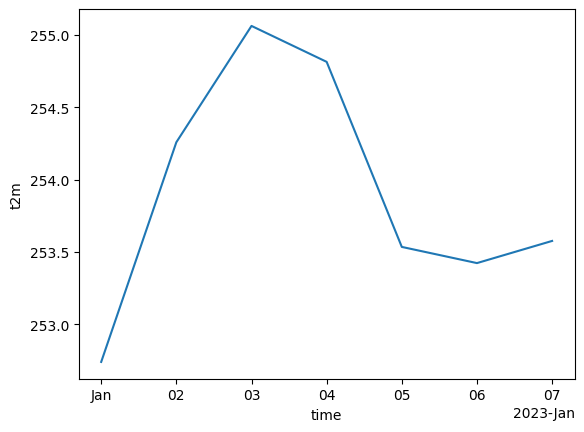

```python
ts['t2m'].plot()
```

### 3. Heatmap query (single layer)

Get a single-layer, aggregated heatmap of a variable at a **certain spatial area** in a **certain period of time**

*E.g., get a heatmap for max temperature for the box area during the period of time*

```python
hm = heat_map_query_single_layer(
    variable=VARIABLE,
    min_lat=MIN_LAT,
    max_lat=MAX_LAT,
    min_lon=MIN_LON,
    max_lon=MAX_LON,
    start_datetime=START_DATETIME,
    end_datetime=END_DATETIME,
    spatial_resolution=0.5,
    spatial_agg_method="max",
)

hm
```

```
<xarray.Dataset> Size: 21kB
Dimensions:    (latitude: 40, longitude: 130)
Coordinates:
  * longitude  (longitude) float32 520B 285.1 285.6 286.1 ... 348.6 349.1 349.6
  * latitude   (latitude) float32 160B 79.88 79.38 78.88 ... 61.38 60.88 60.38
Data variables:
    t2m        (latitude, longitude) float32 21kB 249.1 249.0 ... 280.0 280.0
```

#### 3.1 visualize single-layer heatmap

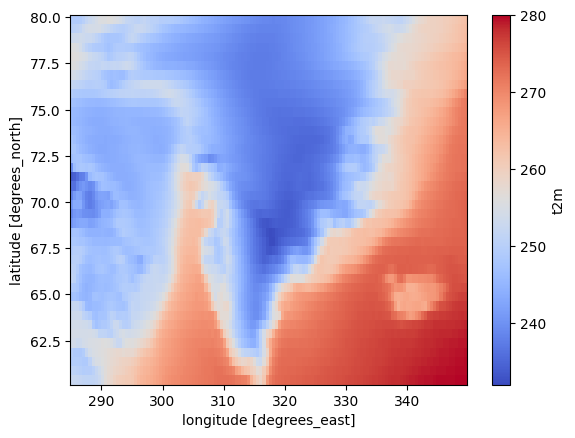

```python
hm['t2m'].plot(cmap="coolwarm")
```

### 4. Heatmap query (multi layer)

Get a multi-layer heatmap of a variable at a **certain spatial area** in a **certain period of time**

Each layer represents a time during the period of time.

AKA. get a raster cube of a variable at a **certain spatial area and spatial resolution**, in a **certain period of time and temporal resolution**.

*E.g., get raster cude of temperature in the box area (at 2degree * 2degree resolution) during the period of time (at daily resolution)*

```python
hmm = heat_map_query_multi_layer(
    variable=VARIABLE,
    min_lat=MIN_LAT,
    max_lat=MAX_LAT,
    min_lon=MIN_LON,
    max_lon=MAX_LON,
    start_datetime=START_DATETIME,
    end_datetime=END_DATETIME,
    spatial_resolution=2,
    spatial_agg_method="mean",
    time_resolution="day",
    time_agg_method="mean",
)

hmm
```

```
<xarray.Dataset> Size: 9kB
Dimensions:    (time: 7, latitude: 10, longitude: 32)
Coordinates:
  * longitude  (longitude) float32 128B 285.9 287.9 289.9 ... 343.9 345.9 347.9
  * latitude   (latitude) float32 40B 79.12 77.12 75.12 ... 65.12 63.12 61.12
  * time       (time) datetime64[ns] 56B 2023-01-01 2023-01-02 ... 2023-01-07
Data variables:
    t2m        (time, latitude, longitude) float32 9kB 248.6 247.6 ... 280.3
Attributes:
    Conventions:  CF-1.6
    history:      2024-03-26 20:03:07 GMT by grib_to_netcdf-2.25.1: /opt/ecmw...
```

#### 4.1 visualize multi-layer heatmap

```python
gv_dataset = gv.Dataset(hmm)
gv_dataset.to(gv.Image)
gv_image = gv_dataset.to(gv.Image)
gv_image.opts(cmap="coolwarm", colorbar=True, tools=["hover"])
gv_image = gv_image * gf.coastline
gv_image.opts(width=700, height=500)
# pn.panel(gv_image, width=700, height=500).servable()
```

### 5. Value criteria query

Get a raster cube where each cell satisfies the value criteria

```python
vc = value_criteria_query(
    variable=VARIABLE,
    min_lat=MIN_LAT,
    max_lat=MAX_LAT,
    min_lon=MIN_LON,
    max_lon=MAX_LON,
    start_datetime=START_DATETIME,
    end_datetime=END_DATETIME,
    spatial_resolution=2,
    spatial_agg_method="max",
    time_resolution="day",
    time_agg_method="max",
    criteria_predicate="<",
    criteria_value=255
)

vc
```

```
<xarray.Dataset> Size: 9kB
Dimensions:    (time: 7, latitude: 10, longitude: 32)
Coordinates:
  * longitude  (longitude) float32 128B 285.9 287.9 289.9 ... 343.9 345.9 347.9
  * latitude   (latitude) float32 40B 79.12 77.12 75.12 ... 65.12 63.12 61.12
  * time       (time) datetime64[ns] 56B 2023-01-01 2023-01-02 ... 2023-01-07
Data variables:
    t2m        (time, latitude, longitude) float32 9kB nan nan nan ... nan nan
Attributes:
    Conventions:  CF-1.6
    history:      2024-03-26 20:03:07 GMT by grib_to_netcdf-2.25.1: /opt/ecmw...
```

#### 5.1 visualize value criteria result

```python
gv_dataset = gv.Dataset(vc)
gv_dataset.to(gv.Image)
gv_image = gv_dataset.to(gv.Image)
gv_image.opts(cmap="coolwarm", colorbar=True, tools=["hover"])
gv_image = gv_image * gf.coastline
gv_image.opts(width=700, height=500)
# pn.panel(gv_image, width=700, height=500).servable()
```

```
BokehModel(combine_events=True, render_bundle={'docs_json': {'091d736a-e645-4e8b-94ff-a79d7b17b6bf': {'version…
```

### 6. Area finding query

Find spatial area that satisfies a certain criteria.

*E.g., find area in the box area where every daily max temperature is < 255*

```python
af = area_finding_query(
    variable=VARIABLE,
    min_lat=MIN_LAT,
    max_lat=MAX_LAT,
    min_lon=MIN_LON,
    max_lon=MAX_LON,
    start_datetime=START_DATETIME,
    end_datetime=END_DATETIME,
    spatial_resolution=2,
    spatial_agg_method="max",
    time_resolution="day",
    time_agg_method="max",
    criteria_predicate="<",
    criteria_value=255,
    any_or_all="all"
)
af
```

```
<xarray.Dataset> Size: 10kB
Dimensions:       (time: 7, latitude: 10, longitude: 32)
Coordinates:
  * longitude     (longitude) float32 128B 285.9 287.9 289.9 ... 345.9 347.9
  * latitude      (latitude) float32 40B 79.12 77.12 75.12 ... 65.12 63.12 61.12
  * time          (time) datetime64[ns] 56B 2023-01-01 2023-01-02 ... 2023-01-07
Data variables:
    t2m           (time, latitude, longitude) float32 9kB nan nan ... nan nan
    spatial_mask  (latitude, longitude) bool 320B False False ... False False
Attributes:
    Conventions:  CF-1.6
    history:      2024-03-26 20:03:07 GMT by grib_to_netcdf-2.25.1: /opt/ecmw...
```

#### 6.1 visualize area finding

```python
df = af["spatial_mask"].to_dataframe().reset_index()
df["latitude"] = df["latitude"] - 1
df["longitude"] = df["longitude"] - 1
df["latitude2"] = df["latitude"] + 2
df["longitude2"] = df["longitude"] + 2
gdf = gpd.GeoDataFrame(df, geometry=[Polygon([(x, y), (x, y2), (x2, y2), (x2, y)]) for x, y, x2, y2 in zip(df["longitude"], df["latitude"], df["longitude2"], df["latitude2"])])


fig = px.choropleth_mapbox(
    gdf,
    geojson=gdf.geometry,
    locations=gdf.index,
    color="spatial_mask",
    mapbox_style="carto-positron",
    center={"lat": gdf["latitude"].mean(), "lon": gdf["longitude"].mean()},
    zoom=1,
)
fig.show()
```

### 7. Time period query

Find time period that satisfies a certain criteria

*E.g., find days during the time period in the box area where all daily max temperature is < 282*

```python
tp = time_period_query(
    variable=VARIABLE,
    min_lat=MIN_LAT,
    max_lat=MAX_LAT,
    min_lon=MIN_LON,
    max_lon=MAX_LON,
    start_datetime=START_DATETIME,
    end_datetime=END_DATETIME,
    spatial_resolution=2,
    spatial_agg_method="max",
    time_resolution="day",
    time_agg_method="max",
    criteria_predicate="<",
    criteria_value=282,
    any_or_all="all"
)

tp
```

```
<xarray.Dataset> Size: 9kB
Dimensions:    (time: 7, latitude: 10, longitude: 32)
Coordinates:
  * longitude  (longitude) float32 128B 285.9 287.9 289.9 ... 343.9 345.9 347.9
  * latitude   (latitude) float32 40B 79.12 77.12 75.12 ... 65.12 63.12 61.12
  * time       (time) datetime64[ns] 56B 2023-01-01 2023-01-02 ... 2023-01-07
Data variables:
    t2m        (time, latitude, longitude) float32 9kB 258.7 257.1 ... 281.7
    time_mask  (time) bool 7B True False False True True True True
Attributes:
    Conventions:  CF-1.6
    history:      2024-03-26 20:03:07 GMT by grib_to_netcdf-2.25.1: /opt/ecmw...
```

#### 7.1 visualize time period finding

```python
df = tp["time_mask"].to_dataframe().reset_index()
fig = px.line(df, x="time", y="time_mask")
fig.update_yaxes(autorange="reversed")
fig.show()
```